# Tarea_diplomado_Paula

Dra. Paula Celis-Plá

2022-10-04

## Descripción del Trabajo

** Este estudio tiene por objetivo, evaluar la diferencias estadísticas de las variables fisiológicas y variables ambientales respecto a la variable categórica estación del Año con 4 niveles; Autumn, Winter, Spring y Summer, la variable tiempo (expresada en días) con 3 niveles; dia 1, dia 2 y dia 3, y la variable Replica con 9 valores.

**Las variables fisológicas analizadas en este estudio fueron Clorofila a o Cla (expresada en microgramos  
* gramos-1 de peso seco), Clorofila c = Clc (expresada en microgramos * gramos-1 de peso seco), Carotenos o Car (expresada en microgramos * gramos-1 de peso seco), Compuestos fenólicos o PC (expresada en miligramos * gramos-1 de peso seco), Actividad antioxidante o DPPH = actividad antioxidante (expresada en micromol de unidades de trolox * gramos-1 de peso seco), y las variables ambientales; temperatura (expresada en °C), pH (expresada en unidades de pH), Salinidad (expresada en psu) y Radiación fotosinteticamente activa o PAR (expresada en micromoles de fotones * m-2 * s-1), con un total de 108 observaciones.

## Variables categóricas Seasons, time y replicate asigna factor

## Transforma variables a factores

```r
Datos_Proyecto <- read_excel("Datos_Proyecto.xlsx")
summary(Datos_Proyecto)
```

```
##    Seasons              time            Replicate              Chla
##  Length:108         Length:108         Length:108         Min.   :0.6730
##  Class :character   Class :character   Class :character   1st Qu.:0.9888
##  Mode  :character   Mode  :character   Mode  :character   Median :1.1660
##                                                           Mean   :1.1856
##                                                           3rd Qu.:1.3813
##                                                           Max.   :1.9690
##       Chlc              Car               PC              DPPH
##  Min.   :0.01000   Min.   :0.4190   Min.   : 4.600   Min.   : 3.792
##  1st Qu.:0.06775   1st Qu.:0.6240   1st Qu.: 9.953   1st Qu.: 6.539
##  Median :0.09500   Median :0.7520   Median :13.815   Median : 7.769
##  Mean   :0.09365   Mean   :0.7557   Mean   :15.153   Mean   : 7.444
##  3rd Qu.:0.10975   3rd Qu.:0.8780   3rd Qu.:18.990   3rd Qu.: 8.433
##  Max.   :0.22100   Max.   :1.2080   Max.   :37.340   Max.   :10.097
##   Temperature          pH           Salinity          PAR
##  Min.   :11.54   Min.   :7.620   Min.   :16.44   Min.   :   9.768
##  1st Qu.:12.47   1st Qu.:7.850   1st Qu.:29.62   1st Qu.: 196.000
##  Median :13.29   Median :7.960   Median :34.10   Median : 525.793
##  Mean   :14.08   Mean   :7.982   Mean   :30.49   Mean   : 569.983
##  3rd Qu.:15.35   3rd Qu.:8.150   3rd Qu.:34.63   3rd Qu.: 764.500
##  Max.   :18.02   Max.   :8.500   Max.   :34.90   Max.   :1921.000
```

```r
Datos_Proyecto$Seasons <- as.factor(Datos_Proyecto$Seasons)
Datos_Proyecto$time <- as.factor(Datos_Proyecto$time)
Datos_Proyecto$Replicate <- as.factor(Datos_Proyecto$Replicate)
summary(Datos_Proyecto)
```

```
##    Seasons      time      Replicate       Chla             Chlc
##  Autumn:27   day 1:36   R1     :12   Min.   :0.6730   Min.   :0.01000
##  Spring:27   day 2:36   R2     :12   1st Qu.:0.9888   1st Qu.:0.06775
##  Summer:27   day 3:36   R3     :12   Median :1.1660   Median :0.09500
##  Winter:27              R4     :12   Mean   :1.1856   Mean   :0.09365
##                         R5     :12   3rd Qu.:1.3813   3rd Qu.:0.10975
##                         R6     :12   Max.   :1.9690   Max.   :0.22100
##                         (Other):36
##       Car               PC              DPPH         Temperature
##  Min.   :0.4190   Min.   : 4.600   Min.   : 3.792   Min.   :11.54
##  1st Qu.:0.6240   1st Qu.: 9.953   1st Qu.: 6.539   1st Qu.:12.47
##  Median :0.7520   Median :13.815   Median : 7.769   Median :13.29
##  Mean   :0.7557   Mean   :15.153   Mean   : 7.444   Mean   :14.08
##  3rd Qu.:0.8780   3rd Qu.:18.990   3rd Qu.: 8.433   3rd Qu.:15.35
##  Max.   :1.2080   Max.   :37.340   Max.   :10.097   Max.   :18.02
##
##        pH           Salinity          PAR
##  Min.   :7.620   Min.   :16.44   Min.   :   9.768
##  1st Qu.:7.850   1st Qu.:29.62   1st Qu.: 196.000
##  Median :7.960   Median :34.10   Median : 525.793
##  Mean   :7.982   Mean   :30.49   Mean   : 569.983
##  3rd Qu.:8.150   3rd Qu.:34.63   3rd Qu.: 764.500
##  Max.   :8.500   Max.   :34.90   Max.   :1921.000
##
```

## Histogramas con etiquetas y títulos

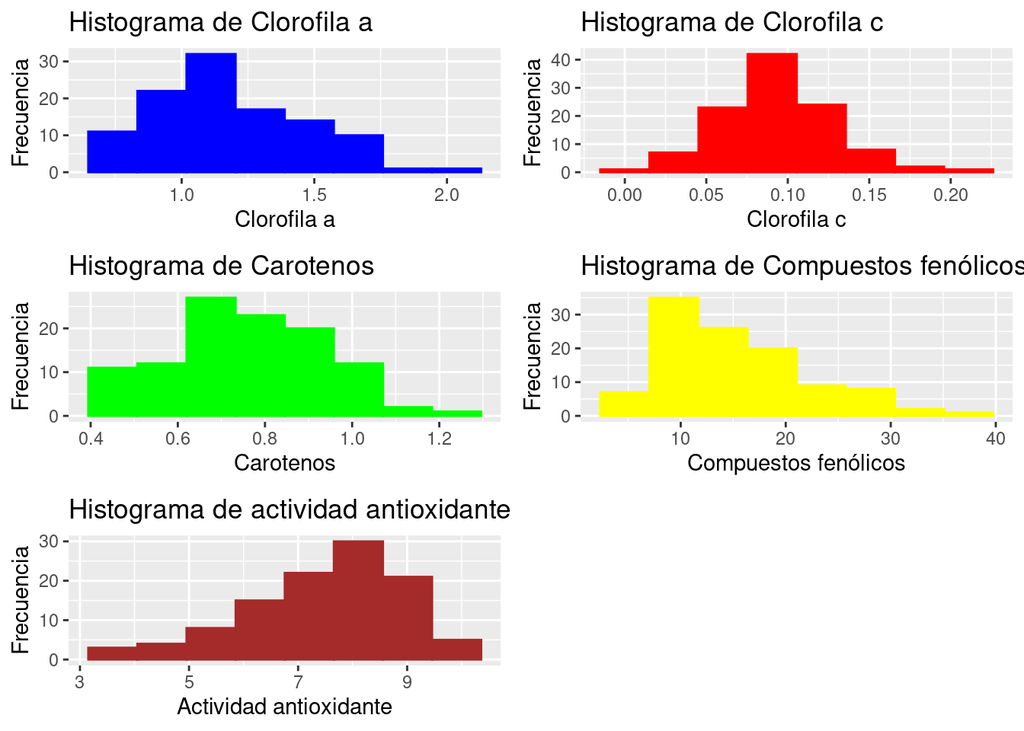

```r
p1 <- ggplot(Datos_Proyecto, aes(Chla)) + geom_histogram(bins = 8, color ="blue", fill="blue")+ labs(title="Histograma de Clorofila a", x="Clorofila a", y="Frecuencia")

p2 <- ggplot(Datos_Proyecto, aes(Chlc)) + geom_histogram(bins = 8, color ="red", fill="red")+ labs(title="Histograma de Clorofila c", x="Clorofila c", y="Frecuencia")
p3 <- ggplot(Datos_Proyecto, aes(Car)) + geom_histogram(bins = 8, color ="green", fill="green")+ labs(title="Histograma de Carotenos", x="Carotenos", y="Frecuencia")
p4 <- ggplot(Datos_Proyecto, aes(PC)) + geom_histogram(bins = 8, color ="yellow", fill="yellow")+ labs(title="Histograma de Compuestos fenólicos", x="Compuestos fenólicos", y="Frecuencia")
p5 <- ggplot(Datos_Proyecto, aes(DPPH)) + geom_histogram(bins = 8, color ="brown", fill="brown")+ labs(title="Histograma de actividad antioxidante", x="Actividad antioxidante", y="Frecuencia")
p6 <- ggplot(Datos_Proyecto, aes(Temperature)) + geom_histogram(bins = 8, color ="pink", fill="pink")+ labs(title="Histograma de Temperatura", x="Temperature", y="Frecuencia")
p7 <- ggplot(Datos_Proyecto, aes(pH)) + geom_histogram(bins = 8, color ="blue", fill="blue")+ labs(title="Histograma de pH", x="pH", y="Frecuencia")
p8 <- ggplot(Datos_Proyecto, aes(Salinity)) + geom_histogram(bins = 8, color ="red", fill="red")+ labs(title="Histograma de Salinidad", x="Salinidad", y="Frecuencia")
p9 <- ggplot(Datos_Proyecto, aes(PAR)) + geom_histogram(bins = 8, color ="green", fill="green")+ labs(title="Histograma de Radiación PAR", x="PAR", y="Frecuencia")

gridExtra::grid.arrange(p1, p2, p3, p4, p5, ncol = 2)
```

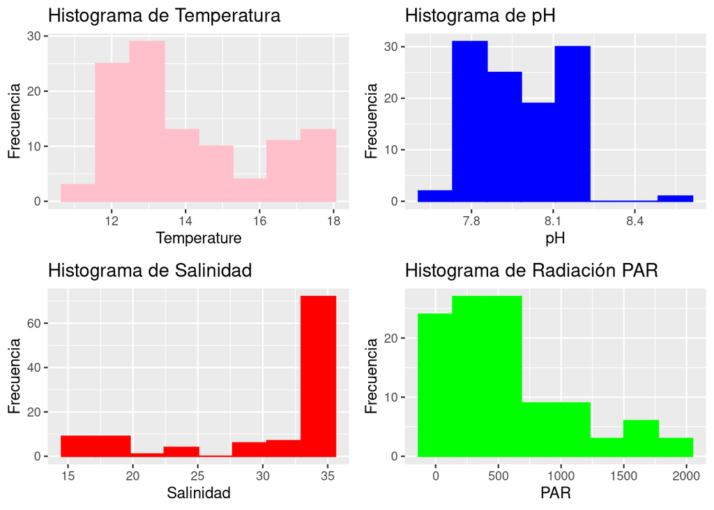

```r
gridExtra::grid.arrange(p6, p7, p8, p9, ncol = 2)
```

## 4. Datos balanceados y tablas de frecuencia

** Los datos estan balanceados

```r
str(Datos_Proyecto)
```

```
## tibble [108 × 12] (S3: tbl_df/tbl/data.frame)
##  $ Seasons    : Factor w/ 4 levels "Autumn","Spring",..: 1 1 1 1 1 1 1 1 1 1 ...
##  $ time       : Factor w/ 3 levels "day 1","day 2",..: 1 1 1 1 1 1 1 1 1 2 ...
##  $ Replicate  : Factor w/ 9 levels "R1","R2","R3",..: 1 2 3 4 5 6 7 8 9 1 ...
##  $ Chla       : num [1:108] 1.04 1.6 1.52 1.48 1.14 ...
##  $ Chlc       : num [1:108] 0.095 0.155 0.143 0.152 0.108 0.115 0.148 0.105 0.102 0.134 ...
##  $ Car        : num [1:108] 0.605 0.954 0.931 0.905 0.694 0.752 0.884 0.659 0.62 0.937 ...
##  $ PC         : num [1:108] 9.12 13.87 15.83 19.89 19.81 ...
##  $ DPPH       : num [1:108] 7.58 6.08 7.81 7.02 7.2 ...
##  $ Temperature: num [1:108] 12.3 12.3 12.3 12.3 12.3 ...
##  $ pH         : num [1:108] 7.84 7.84 7.84 7.85 7.85 7.85 7.88 7.88 7.88 7.84 ...
##  $ Salinity   : num [1:108] 33.7 33.7 33.7 17.9 17.9 ...
##  $ PAR        : num [1:108] 594 594 594 1563 1563 ...
```

```r
knitr::kable(table(Datos_Proyecto$Seasons, Datos_Proyecto$time), caption = "Tabla de contingencia")
```

Tabla de contingencia

|  | day 1 | day 2 | day 3 |
| --- | --- | --- | --- |
| Autumn | 9 | 9 | 9 |
| Spring | 9 | 9 | 9 |
| Summer | 9 | 9 | 9 |
| Winter | 9 | 9 | 9 |

## 5. Relación entre variables cuantitativas y factores

** No se incluiran las variables Seasons, time, y Replicate porque son variables categóricas.

```r
summary(Datos_Proyecto)
```

```
##    Seasons      time      Replicate       Chla             Chlc
##  Autumn:27   day 1:36   R1     :12   Min.   :0.6730   Min.   :0.01000
##  Spring:27   day 2:36   R2     :12   1st Qu.:0.9888   1st Qu.:0.06775
##  Summer:27   day 3:36   R3     :12   Median :1.1660   Median :0.09500
##  Winter:27              R4     :12   Mean   :1.1856   Mean   :0.09365
##                         R5     :12   3rd Qu.:1.3813   3rd Qu.:0.10975
##                         R6     :12   Max.   :1.9690   Max.   :0.22100
##                         (Other):36
##       Car               PC              DPPH         Temperature
##  Min.   :0.4190   Min.   : 4.600   Min.   : 3.792   Min.   :11.54
##  1st Qu.:0.6240   1st Qu.: 9.953   1st Qu.: 6.539   1st Qu.:12.47
##  Median :0.7520   Median :13.815   Median : 7.769   Median :13.29
##  Mean   :0.7557   Mean   :15.153   Mean   : 7.444   Mean   :14.08
##  3rd Qu.:0.8780   3rd Qu.:18.990   3rd Qu.: 8.433   3rd Qu.:15.35
##  Max.   :1.2080   Max.   :37.340   Max.   :10.097   Max.   :18.02
##
##        pH           Salinity          PAR
##  Min.   :7.620   Min.   :16.44   Min.   :   9.768
##  1st Qu.:7.850   1st Qu.:29.62   1st Qu.: 196.000
##  Median :7.960   Median :34.10   Median : 525.793
##  Mean   :7.982   Mean   :30.49   Mean   : 569.983
##  3rd Qu.:8.150   3rd Qu.:34.63   3rd Qu.: 764.500
##  Max.   :8.500   Max.   :34.90   Max.   :1921.000
##
```

## 5. Graficas de correlación de variables continuas (pearson)

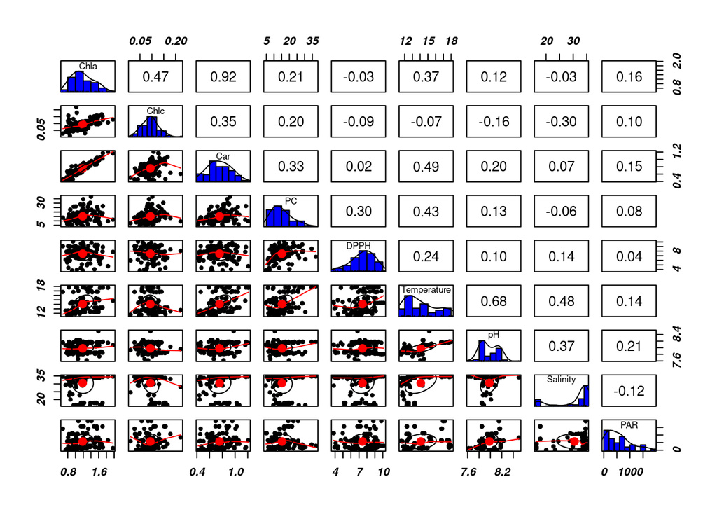

```r
pairs.panels(Datos_Proyecto[,4:12], method = "pearson", hist.col = "blue", density = TRUE, font=4)
```

** Se muestran correlación entre las primeras 4 variables continuas

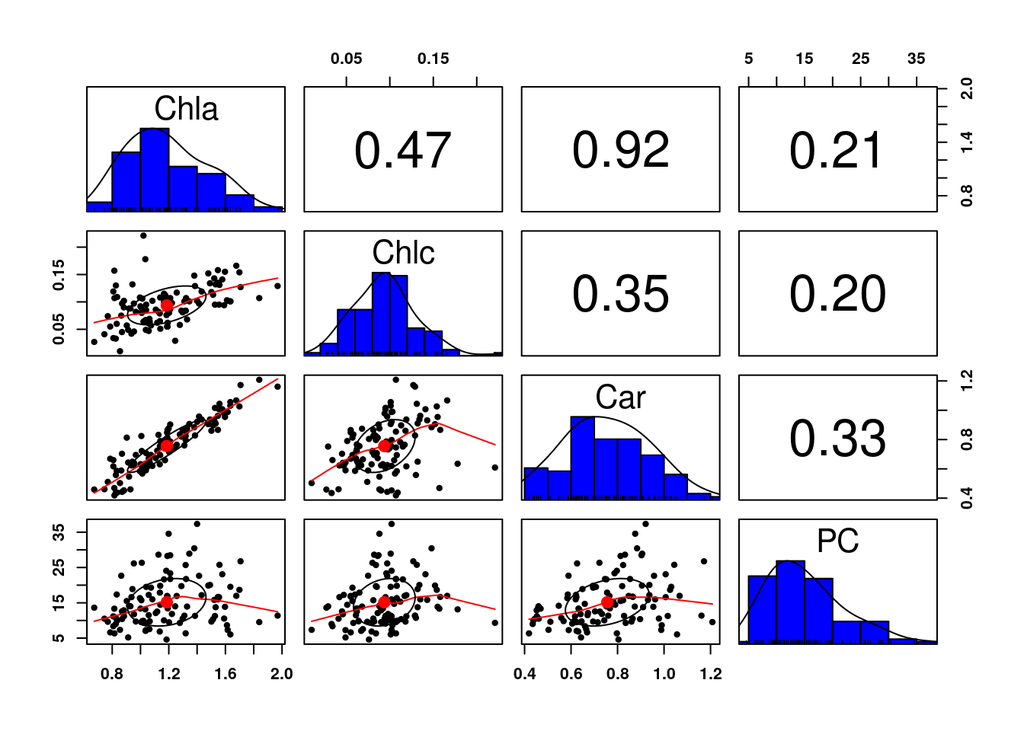

```r
pairs.panels(Datos_Proyecto[,4:7], method = "pearson", hist.col = "blue", density = TRUE, font=2)
```

** Se muestra correlación entre las segundas 4 variables continuas

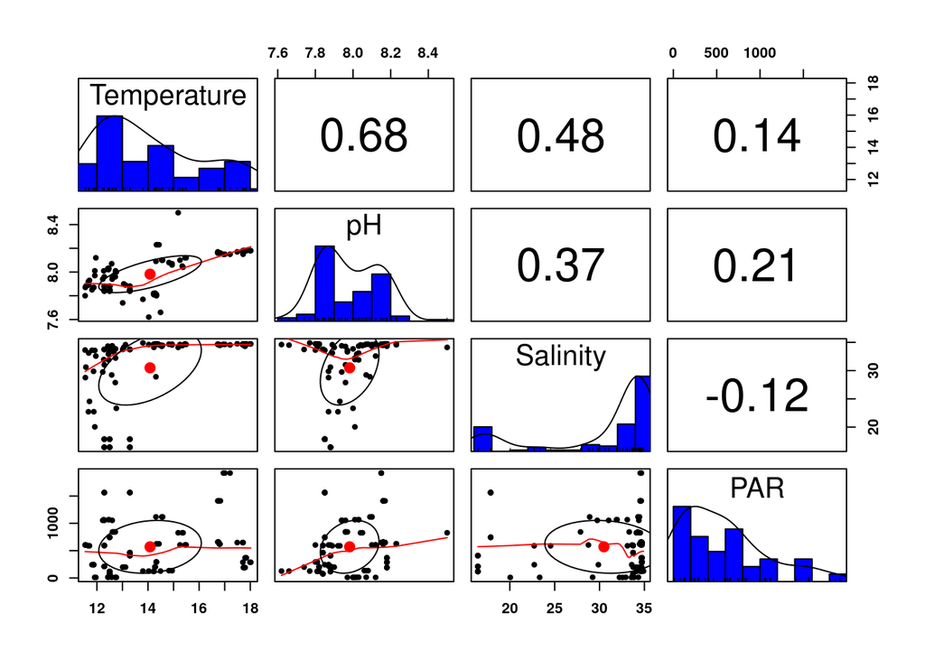

```r
pairs.panels(Datos_Proyecto[,9:12], method = "pearson", hist.col = "blue", density = TRUE, font=2)
```

## 5. Relación entre variables continuas y factores (boxplot)

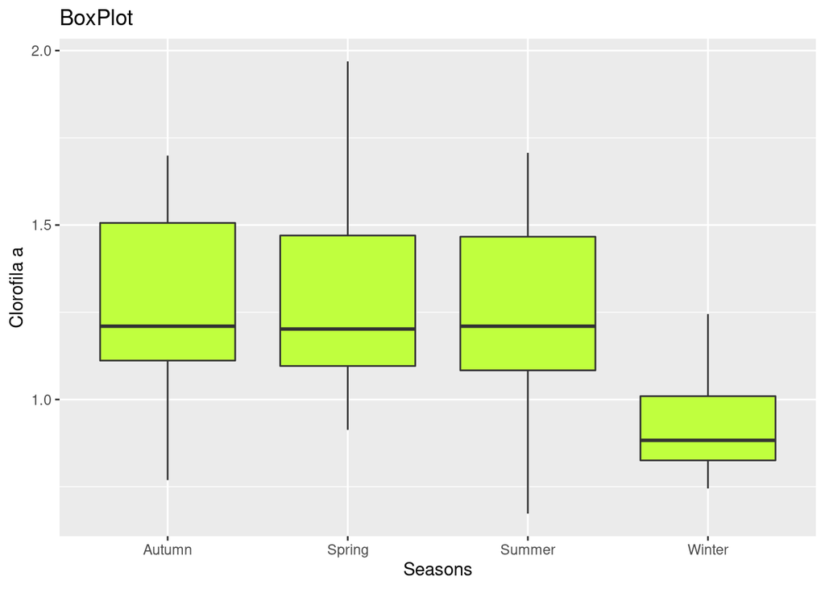

```r
ggplot(Datos_Proyecto, aes(x= Seasons, y=Chla))+geom_boxplot(fill="olivedrab1")+labs(title = "BoxPlot", x= "Seasons", y= "Clorofila a")
```

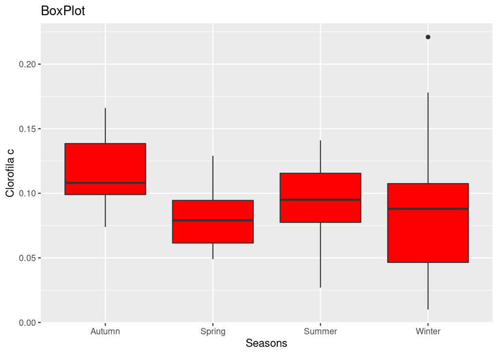

```r
ggplot(Datos_Proyecto, aes(x= Seasons, y=Chlc))+geom_boxplot(fill="red")+labs(title = "BoxPlot", x= "Seasons", y= "Clorofila c")
```

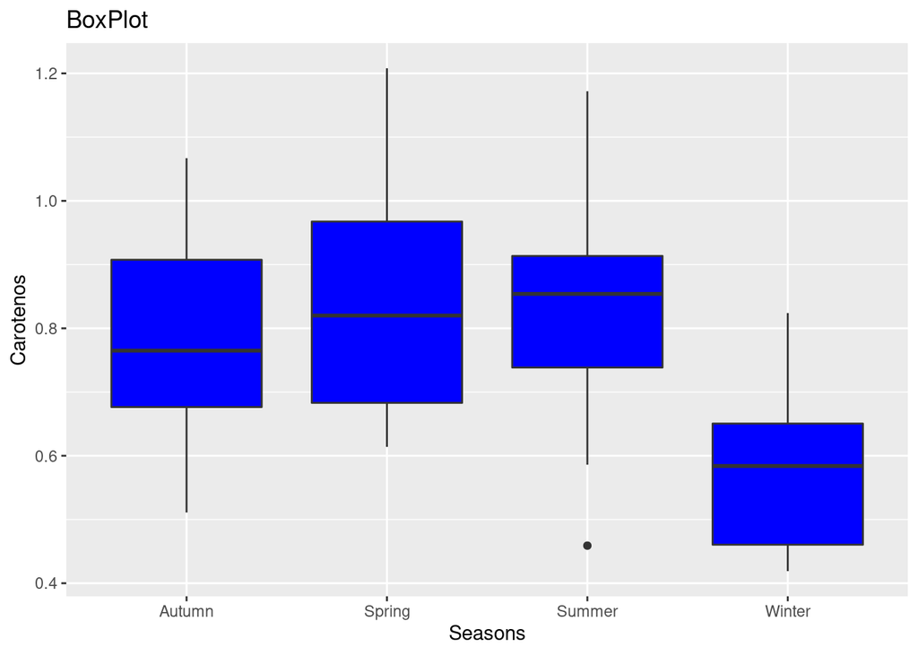

```r
ggplot(Datos_Proyecto, aes(x= Seasons, y=Car))+geom_boxplot(fill="blue")+labs(title = "BoxPlot", x= "Seasons", y= "Carotenos")
```

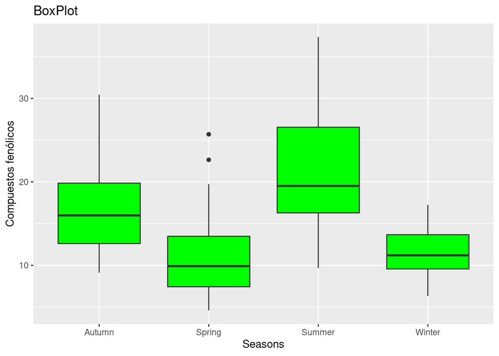

```r
ggplot(Datos_Proyecto, aes(x= Seasons, y=PC))+geom_boxplot(fill="green")+labs(title = "BoxPlot", x= "Seasons", y= "Compuestos fenólicos")
```

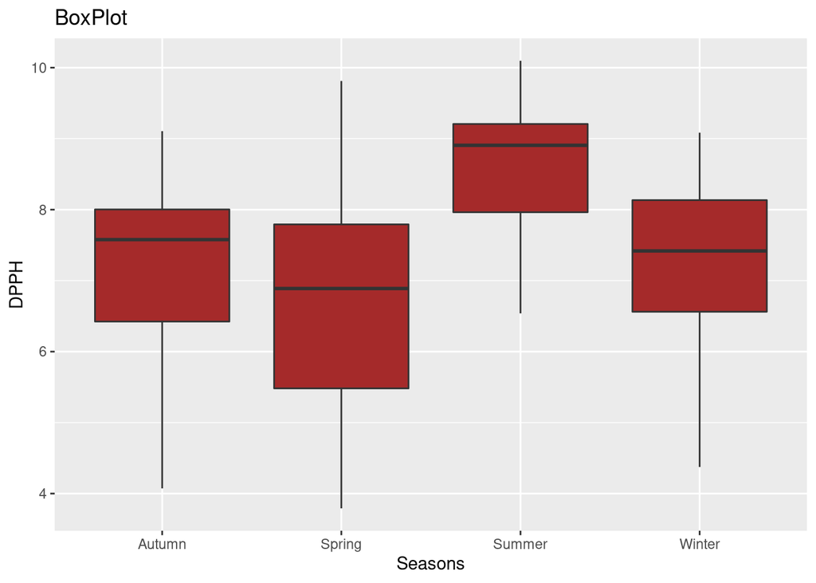

```r
ggplot(Datos_Proyecto, aes(x= Seasons, y=DPPH))+geom_boxplot(fill="brown")+labs(title = "BoxPlot", x= "Seasons", y= "DPPH")
```

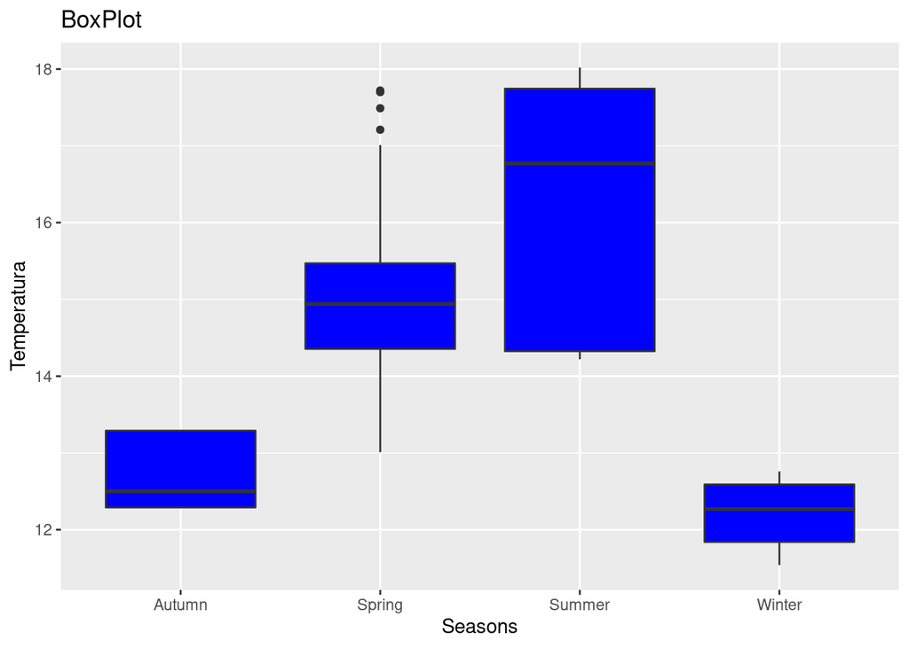

```r
ggplot(Datos_Proyecto, aes(x= Seasons, y=Temperature))+geom_boxplot(fill="blue")+labs(title = "BoxPlot", x= "Seasons", y= "Temperatura")
```

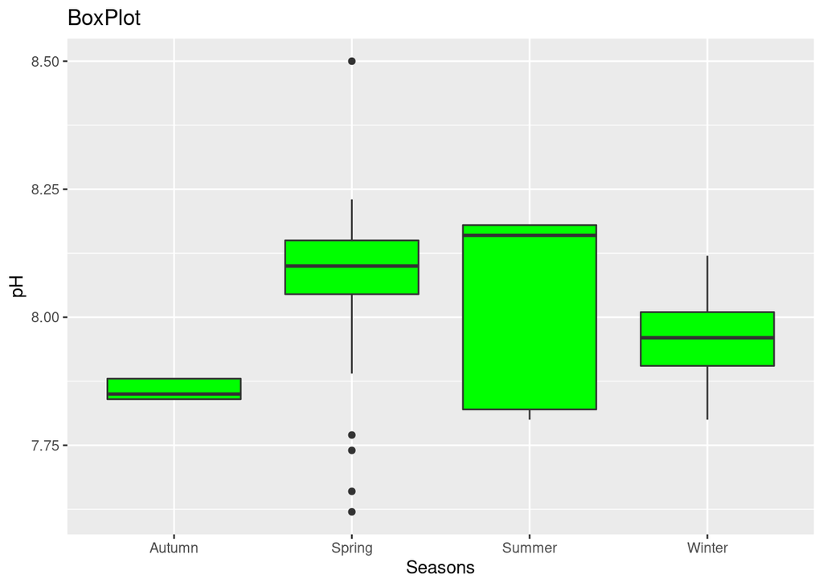

```r
ggplot(Datos_Proyecto, aes(x= Seasons, y=pH))+geom_boxplot(fill="green")+labs(title = "BoxPlot", x= "Seasons", y= "pH")
```

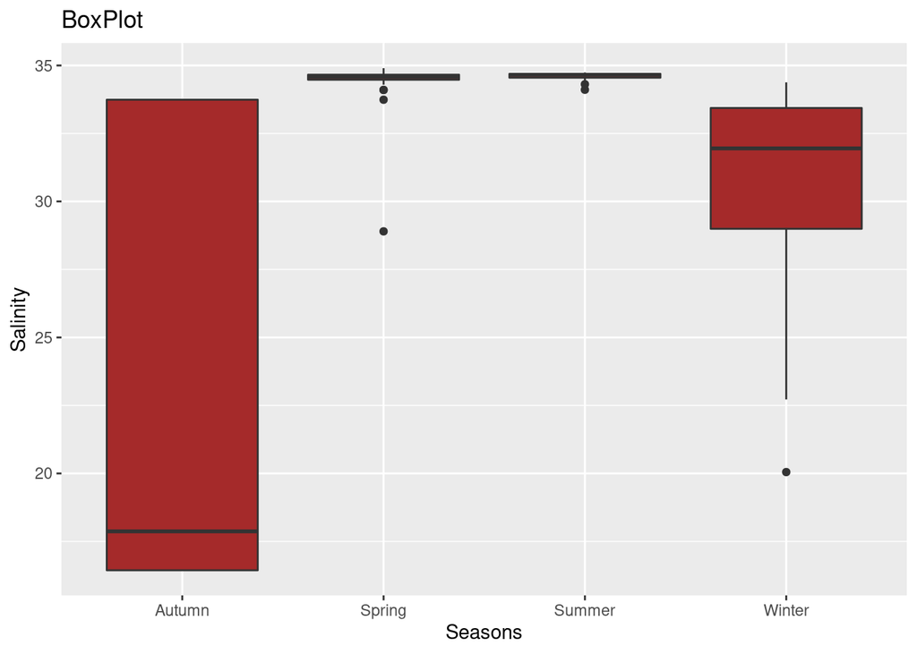

```r
ggplot(Datos_Proyecto, aes(x= Seasons, y=Salinity))+geom_boxplot(fill="brown")+labs(title = "BoxPlot", x= "Seasons", y= "Salinity")
```

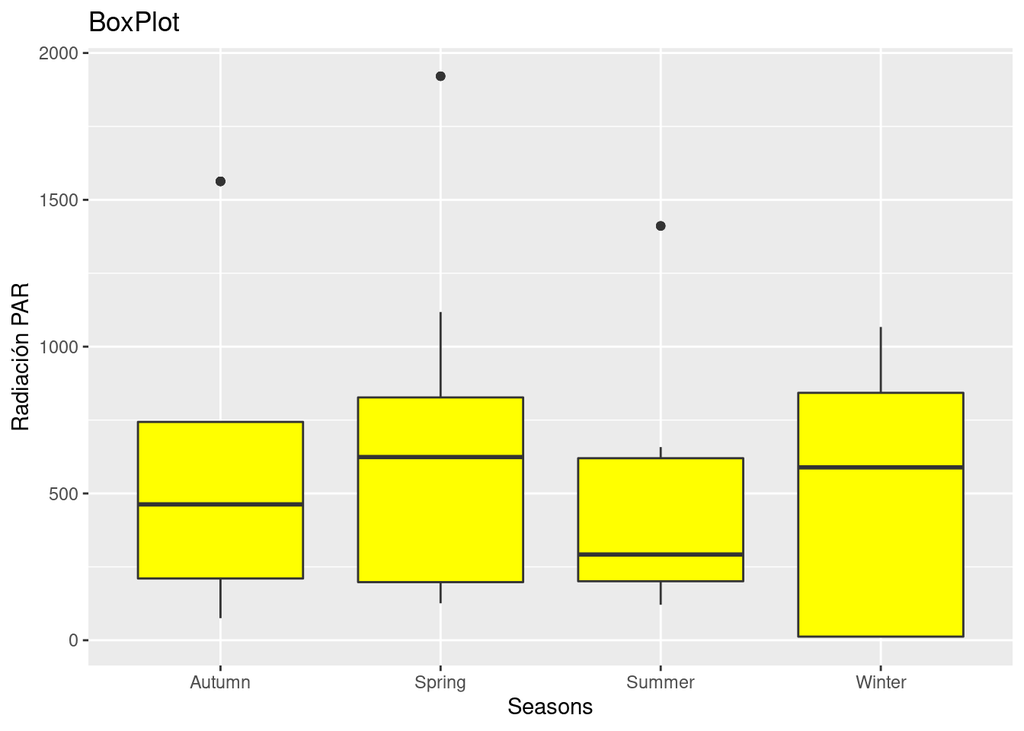

```r
ggplot(Datos_Proyecto, aes(x= Seasons, y=PAR))+geom_boxplot(fill="yellow")+labs(title = "BoxPlot", x= "Seasons", y= "Radiación PAR")
```

## 6. Identificación si existen errores, datos faltantes o error atípico

** En la variable Salinidad, existe poca dispersión de los datos en las estaciones de primavera y verano, se registran datos muy similares, por ellos se observó poca dispersión.

** No existen datos faltantes para cada variable.

** Los errores típicos en las variables se identifican a continuación;

## 7. Resumen de los datos con tablas y estadística descriptiva

```r
Datos_Proyecto <- read_excel("Datos_Proyecto.xlsx" , sheet= 1)
head(Datos_Proyecto)
```

```
## # A tibble: 6 × 12
##   Seasons time  Replicate  Chla  Chlc   Car    PC  DPPH Temperat…¹    pH Salin…²
##   <chr>   <chr> <chr>     <dbl> <dbl> <dbl> <dbl> <dbl>      <dbl> <dbl>   <dbl>
## 1 Autumn  day 1 R1         1.04 0.095 0.605  9.12  7.58       12.3  7.84    33.7
## 2 Autumn  day 1 R2         1.60 0.155 0.954 13.9   6.08       12.3  7.84    33.7
## 3 Autumn  day 1 R3         1.52 0.143 0.931 15.8   7.81       12.3  7.84    33.7
## 4 Autumn  day 1 R4         1.48 0.152 0.905 19.9   7.02       12.3  7.85    17.9
## 5 Autumn  day 1 R5         1.14 0.108 0.694 19.8   7.20       12.3  7.85    17.9
## 6 Autumn  day 1 R6         1.17 0.115 0.752 21.6   5.12       12.3  7.85    17.9
## # … with 1 more variable: PAR <dbl>, and abbreviated variable names
## #   ¹Temperature, ²Salinity
```

```r
select(Datos_Proyecto, Chla, Chlc, Car, DPPH)
```

```
## # A tibble: 108 × 4
##     Chla  Chlc   Car  DPPH
##    <dbl> <dbl> <dbl> <dbl>
##  1  1.04 0.095 0.605  7.58
##  2  1.60 0.155 0.954  6.08
##  3  1.52 0.143 0.931  7.81
##  4  1.48 0.152 0.905  7.02
##  5  1.14 0.108 0.694  7.20
##  6  1.17 0.115 0.752  5.12
##  7  1.38 0.148 0.884  6.24
##  8  1.17 0.105 0.659  6.47
##  9  1.08 0.102 0.62   6.38
## 10  1.49 0.134 0.937  4.07
## # … with 98 more rows
```

```r
Datos_tab <- Datos_Proyecto %>% group_by(Seasons) %>% summarize(n = n(),
Promedio_Chla = mean(Chla), Maximo_Chla = max(Chla), Promedio_Chlc = mean(Chlc), Maximo_Chlc = max(Chlc), Promedio_Car = mean(Car), Maximo_Car = max(Car), Promedio_PC = mean(PC), Maximo_PC = max(PC), Promedio_DPPH = mean(DPPH), Maximo_DPPH = max(DPPH), Promedio_Temperature = mean(Temperature), Maximo_Temperature = max(Temperature),Promedio_pH = mean(pH), Maximo_pH = max(pH), Promedio_Salinity = mean(Salinity), Maximo_Salinity = max(Salinity), Promedio_PAR = mean(PAR), Maximo_PAR = max(PAR))

Datos_tab
```

```
## # A tibble: 4 × 20
##   Seasons     n Promed…¹ Maxim…² Prome…³ Maxim…⁴ Prome…⁵ Maxim…⁶ Prome…⁷ Maxim…⁸
##   <chr>   <int>    <dbl>   <dbl>   <dbl>   <dbl>   <dbl>   <dbl>   <dbl>   <dbl>
## 1 Autumn     27    1.28     1.70  0.117    0.166   0.790   1.07     16.5    30.4
## 2 Spring     27    1.30     1.97  0.0781   0.129   0.831   1.21     11.5    25.7
## 3 Summer     27    1.25     1.71  0.0935   0.141   0.825   1.17     21.0    37.3
## 4 Winter     27    0.920    1.25  0.0857   0.221   0.578   0.824    11.5    17.2
## # … with 10 more variables: Promedio_DPPH <dbl>, Maximo_DPPH <dbl>,
## #   Promedio_Temperature <dbl>, Maximo_Temperature <dbl>, Promedio_pH <dbl>,
## #   Maximo_pH <dbl>, Promedio_Salinity <dbl>, Maximo_Salinity <dbl>,
## #   Promedio_PAR <dbl>, Maximo_PAR <dbl>, and abbreviated variable names
## #   ¹Promedio_Chla, ²Maximo_Chla, ³Promedio_Chlc, ⁴Maximo_Chlc, ⁵Promedio_Car,
## #   ⁶Maximo_Car, ⁷Promedio_PC, ⁸Maximo_PC
```

```r
knitr::kable(Datos_tab, caption = "Tabla de medidas resumen")
```

Tabla de medidas resumen

| Seasons | n | Promedio_Chla | Maximo_Chla | Promedio_Chlc | Maximo_Chlc | Promedio_Car | Maximo_Car | Promedio_PC | Maximo_PC | Promedio_DPPH | Maximo_DPPH | Promedio_Temperature | Maximo_Temperature | Promedio_pH | Maximo_pH | Promedio_Salinity | Maximo_Salinity | Promedio_PAR | Maximo_PAR |
| --- | --- | --- | --- | --- | --- | --- | --- | --- | --- | --- | --- | --- | --- | --- | --- | --- | --- | --- | --- |
| Autumn | 27 | 1.2759259 | 1.699 | 0.1173333 | 0.166 | 0.7897407 | 1.067 | 16.53926 | 30.43 | 7.186622 | 9.106009 | 12.69333 | 13.29 | 7.856667 | 7.88 | 22.68333 | 33.74000 | 637.6492 | 1562.997 |
| Spring | 27 | 1.2997407 | 1.969 | 0.0780741 | 0.129 | 0.8307037 | 1.208 | 11.51222 | 25.70 | 6.683110 | 9.812655 | 15.14519 | 17.72 | 8.060741 | 8.50 | 34.32148 | 34.90000 | 689.0000 | 1921.000 |
| Summer | 27 | 1.2466296 | 1.707 | 0.0935185 | 0.141 | 0.8247778 | 1.172 | 21.04630 | 37.34 | 8.555710 | 10.096986 | 16.29444 | 18.02 | 8.051481 | 8.18 | 34.60617 | 34.74265 | 460.8889 | 1411.000 |
| Winter | 27 | 0.9202593 | 1.245 | 0.0856667 | 0.221 | 0.5776667 | 0.824 | 11.51407 | 17.24 | 7.349523 | 9.084461 | 12.18778 | 12.76 | 7.959630 | 8.12 | 30.33926 | 34.38000 | 492.3935 | 1067.000 |

```r
Datos_tab2 <- Datos_Proyecto %>% group_by(time) %>% summarize(n = n(),
Promedio_Chla = mean(Chla), Maximo_Chla = max(Chla), Promedio_Chlc = mean(Chlc), Maximo_Chlc = max(Chlc), Promedio_Car = mean(Car), Maximo_Car = max(Car), Promedio_PC = mean(PC), Maximo_PC = max(PC), Promedio_DPPH = mean(DPPH), Maximo_DPPH = max(DPPH), Promedio_Temperature = mean(Temperature), Maximo_Temperature = max(Temperature),Promedio_pH = mean(pH), Maximo_pH = max(pH), Promedio_Salinity = mean(Salinity), Maximo_Salinity = max(Salinity), Promedio_PAR = mean(PAR), Maximo_PAR = max(PAR))

Datos_tab2
```

```
## # A tibble: 3 × 20
##   time      n Promedio…¹ Maxim…² Prome…³ Maxim…⁴ Prome…⁵ Maxim…⁶ Prome…⁷ Maxim…⁸
##   <chr> <int>      <dbl>   <dbl>   <dbl>   <dbl>   <dbl>   <dbl>   <dbl>   <dbl>
## 1 day 1    36       1.12    1.62  0.0892   0.155   0.707    1.01    14.4    34.6
## 2 day 2    36       1.20    1.70  0.0926   0.178   0.787    1.07    17.8    37.3
## 3 day 3    36       1.23    1.97  0.0992   0.221   0.774    1.21    13.3    26.8
## # … with 10 more variables: Promedio_DPPH <dbl>, Maximo_DPPH <dbl>,
## #   Promedio_Temperature <dbl>, Maximo_Temperature <dbl>, Promedio_pH <dbl>,
## #   Maximo_pH <dbl>, Promedio_Salinity <dbl>, Maximo_Salinity <dbl>,
## #   Promedio_PAR <dbl>, Maximo_PAR <dbl>, and abbreviated variable names
## #   ¹Promedio_Chla, ²Maximo_Chla, ³Promedio_Chlc, ⁴Maximo_Chlc, ⁵Promedio_Car,
## #   ⁶Maximo_Car, ⁷Promedio_PC, ⁸Maximo_PC
```

```r
knitr::kable(Datos_tab2, caption = "Tabla de medidas resumen")
```

Tabla de medidas resumen

| time | n | Promedio_Chla | Maximo_Chla | Promedio_Chlc | Maximo_Chlc | Promedio_Car | Maximo_Car | Promedio_PC | Maximo_PC | Promedio_DPPH | Maximo_DPPH | Promedio_Temperature | Maximo_Temperature | Promedio_pH | Maximo_pH | Promedio_Salinity | Maximo_Salinity | Promedio_PAR | Maximo_PAR |
| --- | --- | --- | --- | --- | --- | --- | --- | --- | --- | --- | --- | --- | --- | --- | --- | --- | --- | --- | --- |
| day 1 | 36 | 1.117389 | 1.616 | 0.0891667 | 0.155 | 0.7066667 | 1.007 | 14.36194 | 34.56 | 7.098292 | 10.096986 | 13.63111 | 17.84 | 7.976667 | 8.23 | 30.40010 | 34.74265 | 670.5323 | 1562.997 |
| day 2 | 36 | 1.204778 | 1.699 | 0.0926111 | 0.178 | 0.7866389 | 1.067 | 17.76972 | 37.34 | 7.457311 | 9.133867 | 14.19778 | 18.02 | 7.971389 | 8.50 | 30.37152 | 34.90000 | 560.3307 | 1562.960 |
| day 3 | 36 | 1.234750 | 1.969 | 0.0991667 | 0.221 | 0.7738611 | 1.208 | 13.32722 | 26.75 | 7.775621 | 9.812655 | 14.41167 | 17.80 | 7.998333 | 8.18 | 30.69107 | 34.75000 | 479.0856 | 1921.000 |

## 8. Utiliza Paquetes para importar datos a R como readxl o similar y paquetes tidyr, dplyr, ggplot2

```r
messy <- read_excel("Datos_Proyecto.xlsx")
summary(messy)
```

```
##    Seasons              time            Replicate              Chla
##  Length:108         Length:108         Length:108         Min.   :0.6730
##  Class :character   Class :character   Class :character   1st Qu.:0.9888
##  Mode  :character   Mode  :character   Mode  :character   Median :1.1660
##                                                           Mean   :1.1856
##                                                           3rd Qu.:1.3813
##                                                           Max.   :1.9690
##       Chlc              Car               PC              DPPH
##  Min.   :0.01000   Min.   :0.4190   Min.   : 4.600   Min.   : 3.792
##  1st Qu.:0.06775   1st Qu.:0.6240   1st Qu.: 9.953   1st Qu.: 6.539
##  Median :0.09500   Median :0.7520   Median :13.815   Median : 7.769
##  Mean   :0.09365   Mean   :0.7557   Mean   :15.153   Mean   : 7.444
##  3rd Qu.:0.10975   3rd Qu.:0.8780   3rd Qu.:18.990   3rd Qu.: 8.433
##  Max.   :0.22100   Max.   :1.2080   Max.   :37.340   Max.   :10.097
##   Temperature          pH           Salinity          PAR
##  Min.   :11.54   Min.   :7.620   Min.   :16.44   Min.   :   9.768
##  1st Qu.:12.47   1st Qu.:7.850   1st Qu.:29.62   1st Qu.: 196.000
##  Median :13.29   Median :7.960   Median :34.10   Median : 525.793
##  Mean   :14.08   Mean   :7.982   Mean   :30.49   Mean   : 569.983
##  3rd Qu.:15.35   3rd Qu.:8.150   3rd Qu.:34.63   3rd Qu.: 764.500
##  Max.   :18.02   Max.   :8.500   Max.   :34.90   Max.   :1921.000
```

[output not shown]